# dblogr

#### Lentil

**Lentil Production**

Graphs of lentil production using FAO data

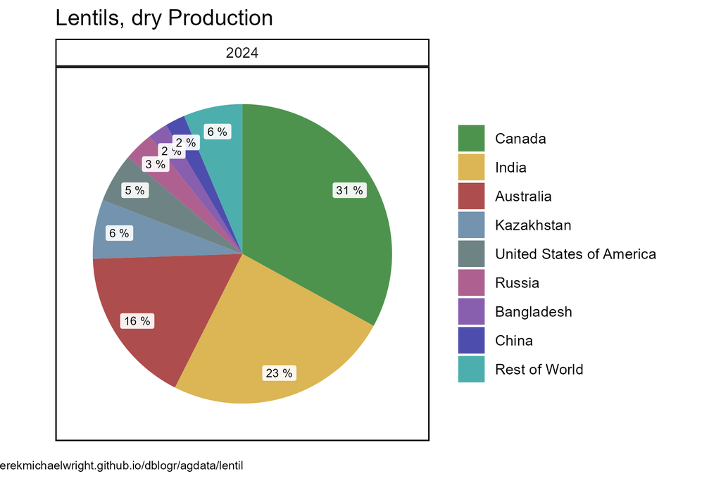

#### Wheat

**Wheat Production**

Graphs of wheat production using FAO data

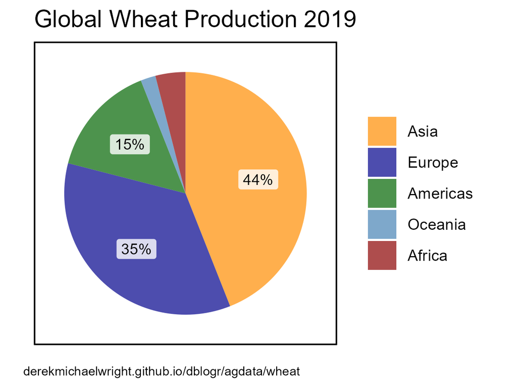

#### Honeybee

**Honeybee Producion**

Graphs of honeybee production using FAO data

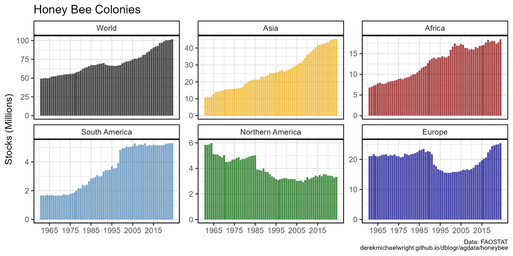

#### India

**Crop Production In India**

Graphs of crop production in India with FAO data

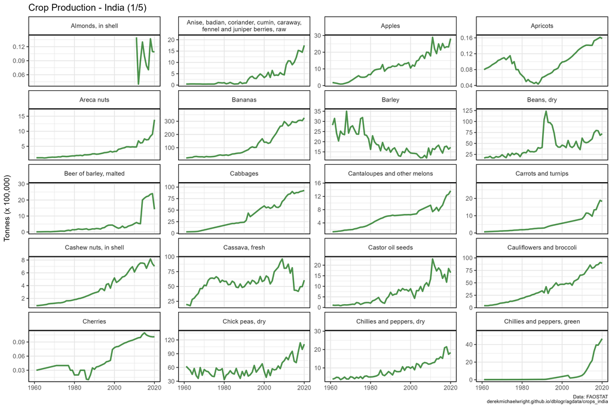

### STATCAN

#### Saskatchewan Crop Production

**Saskatchewan Crop Production**

Graphs of crop production in Saskatchewan using STATCAN data

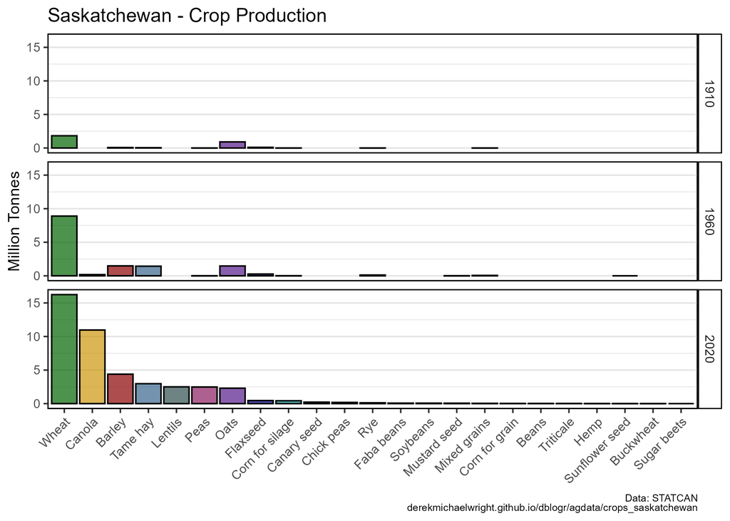

#### Lentil Saskatchewan

**Saskatchewan Lentil Production and Exports**

Graphs of lentil production and exports using SKAG data

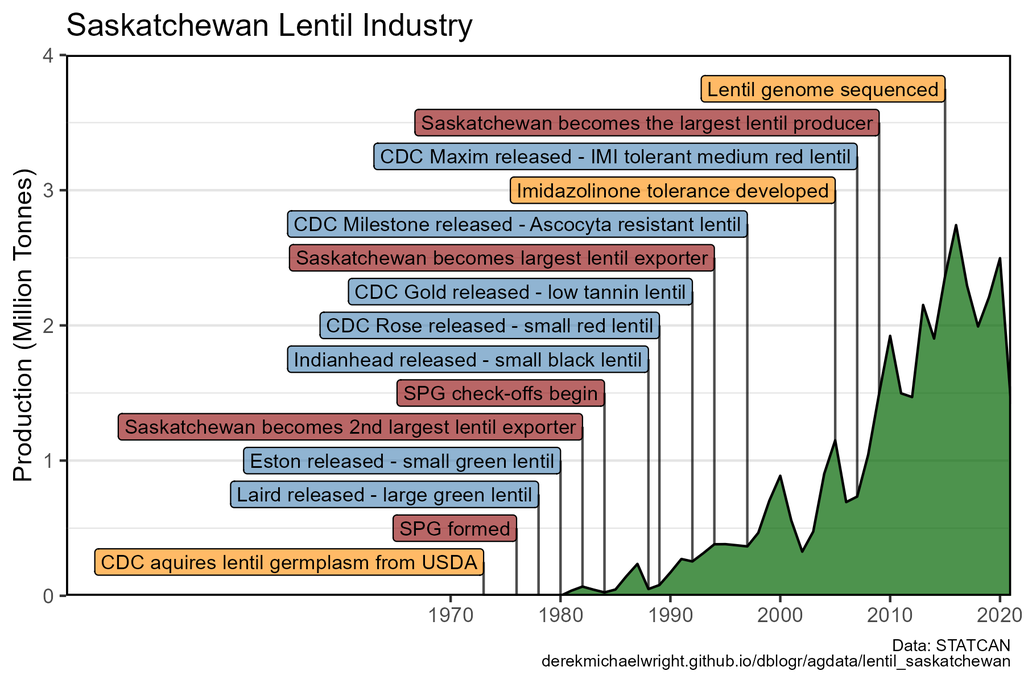

#### Wheat Canada

**Wheat Production in Canada**

Graphs of wheat production using STATCAN data

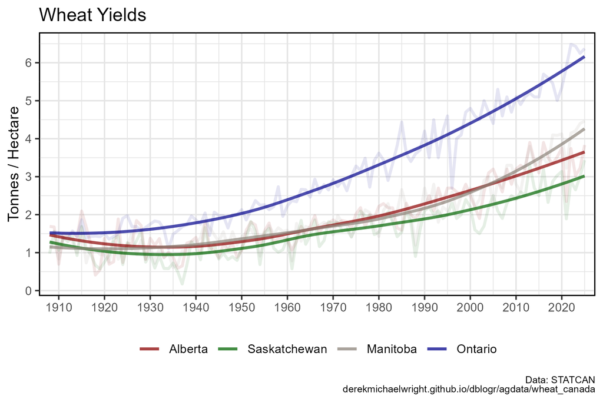

#### Honeybee Canada

**Canadian Honeybee Production**

Graphs of honeybee production in Canada using STATCAN data

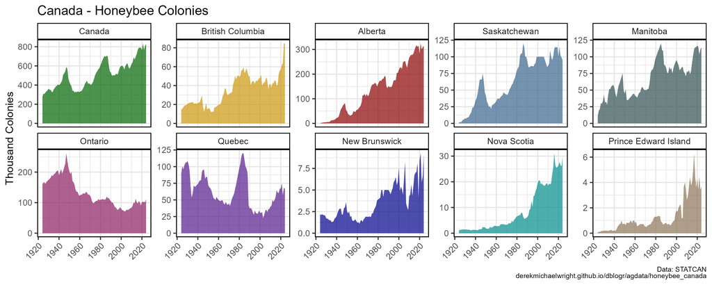

#### Canadian Farmland

**Canadian Farmland**

Graphs about Canadian farmland using STATCAN data

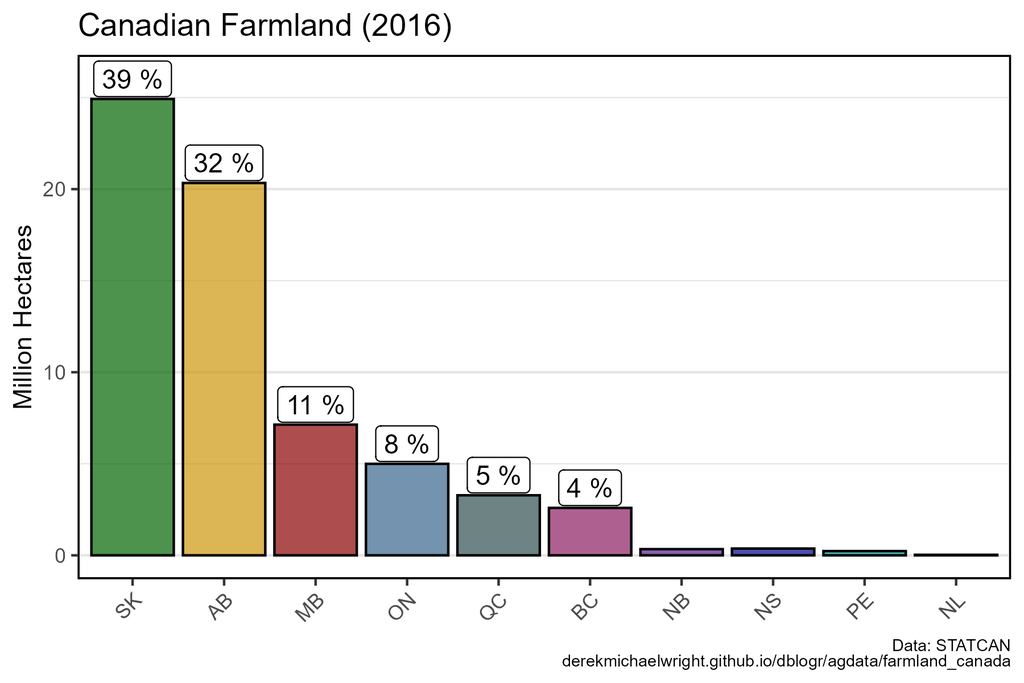

#### Canadian Farmers

**Canadian Farm Operators**

Graphs on Canadian farm operator demographics using STATCAN data

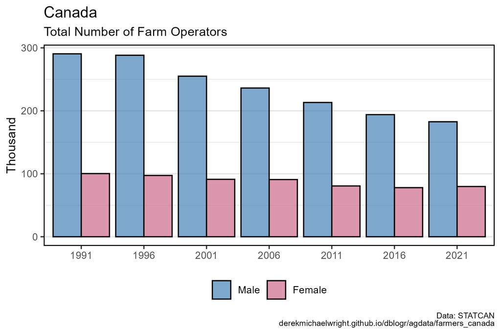

#### Maps of Canadian Crop Production

**Canadian Crop Production**

Graphs of crop production in Canada using STATCAN data

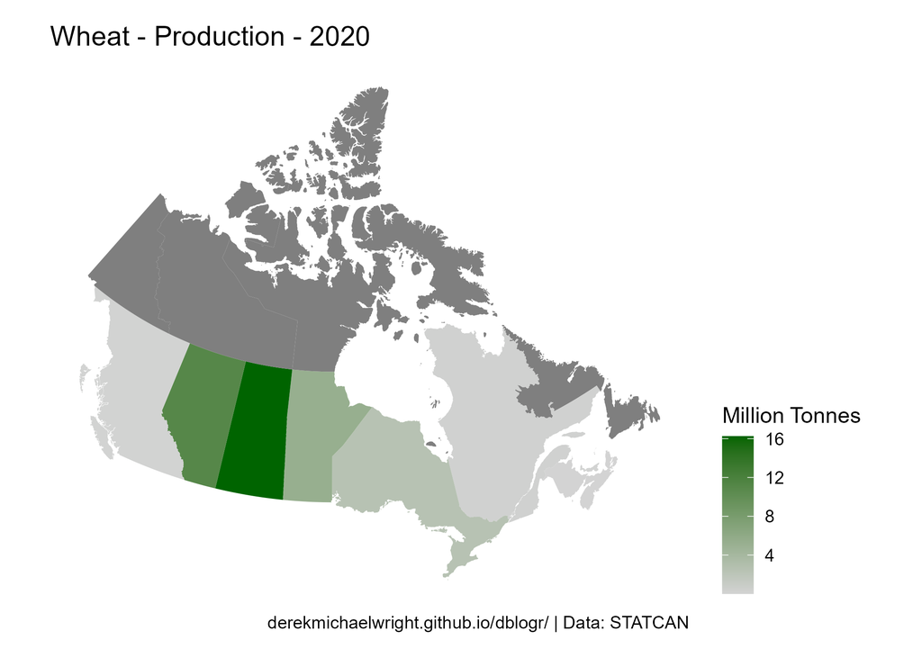

### USDA, ISAAA, *etc*

#### Maize USA

**USA Maize Production**

Graphs of maize production in the USA using USDA data

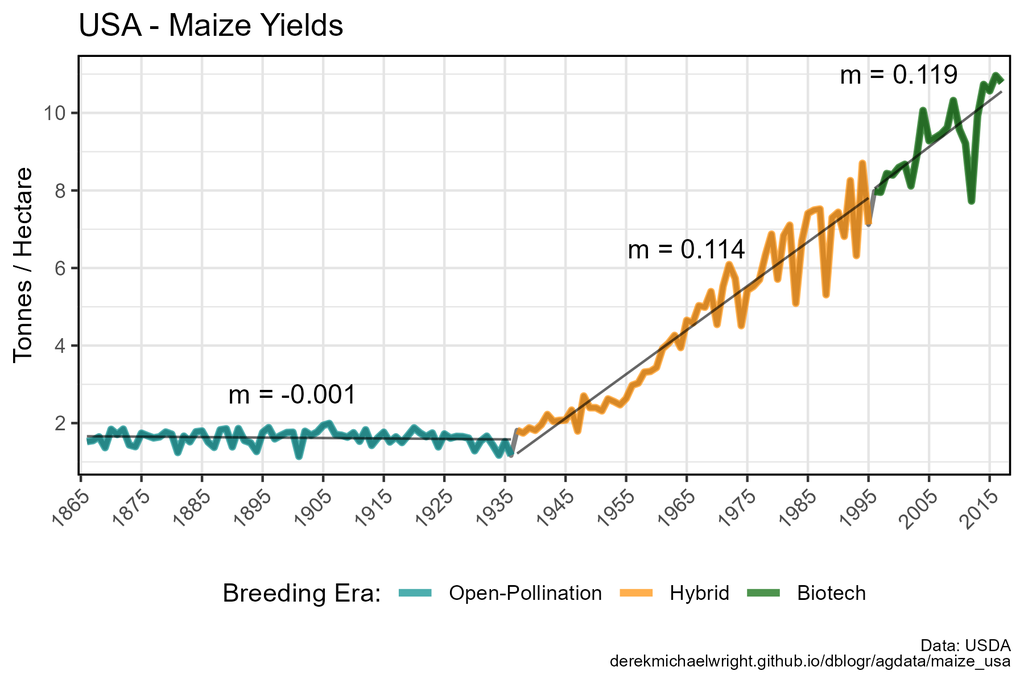

#### Sugarbeet USA

**Sugarbeet Production in USA**

Graphs of sugarbeet production using USDA data

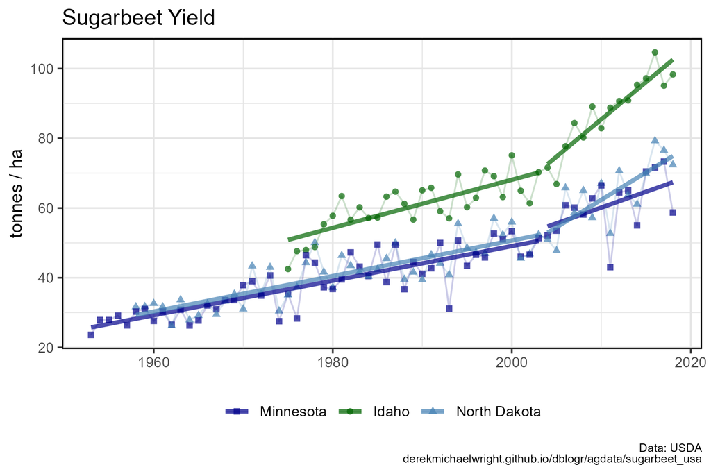

#### GE Crops

**Genetically Engineered Crop Production**

Graphs of GE crop production using ISAAA data

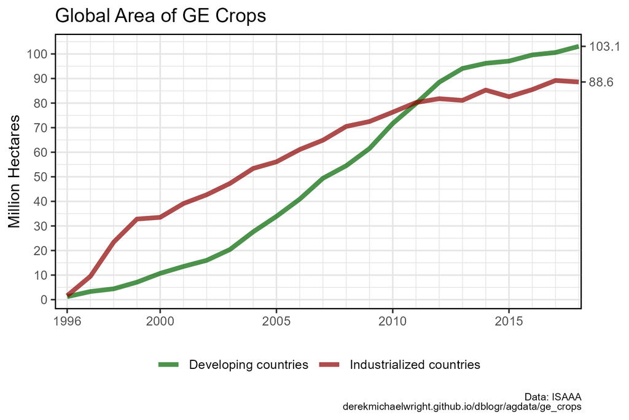

#### GE Crops USA

**Genetically Engineered Crop Production in USA**

Graphs of GE crop production using USDA data

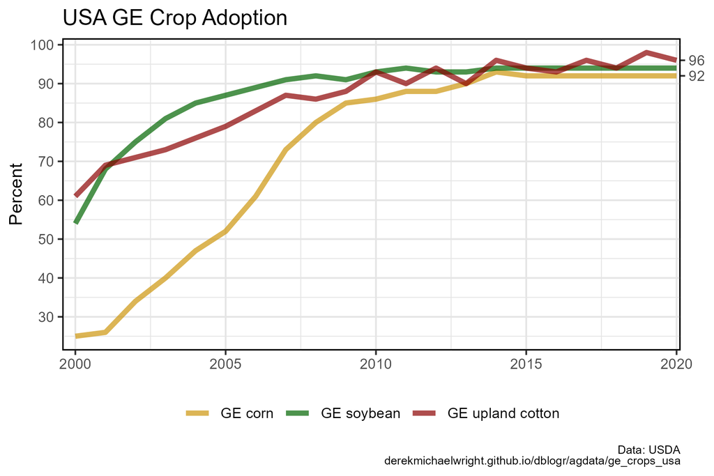

# Blog

## Random Data Visualizations

### Economics

#### Global Energy Use and Poverty

**Global Energy Use and Poverty**

Graphs of global energy use, electricity use, CO2 emissions, GDP, and poverty using data from Our World in Data and IEA

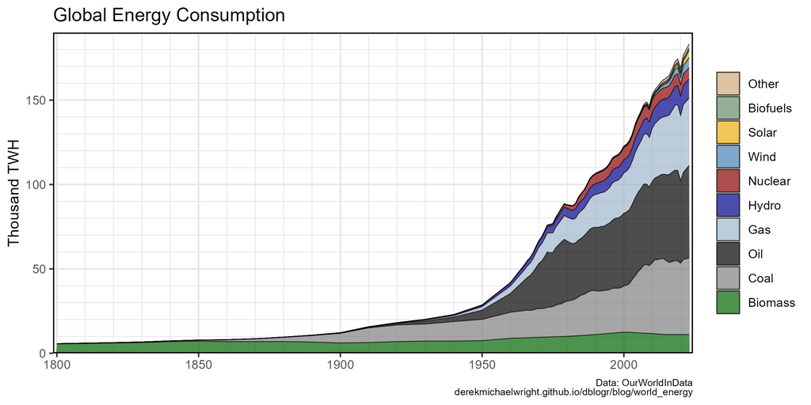

#### Canada Fossil Fuels

**Canadian Fossil Fuel Production and Import**

Graphs of crude oil, natural gas, and coal production, import and export using STATCAN data

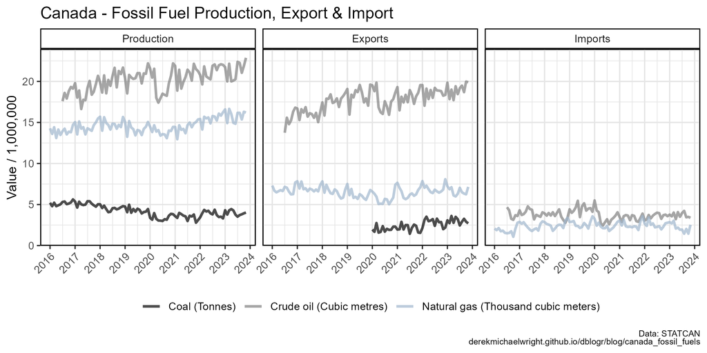

#### Canada Housing

**Housing In Canada**

Graphs of housing data in Canada using STATCAN data

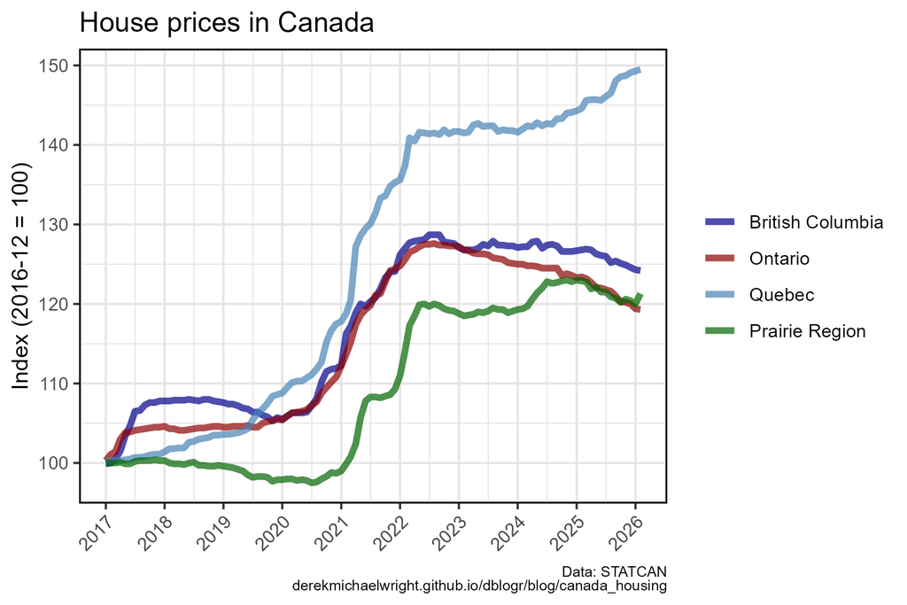

#### Canada Public Private

**Public vs Private Sector Employment in Canada**

Graphs of public vs private sector employment in Canada using STATCAN data

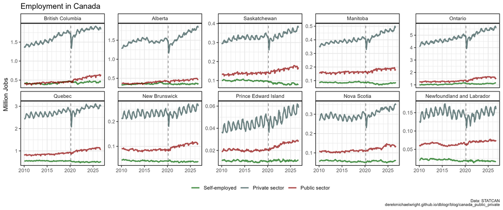

#### Canada Trade

**Canadian Trade - Imports and Exports**

Graphs of trade surplus/deficits with other countries using STATCAN data

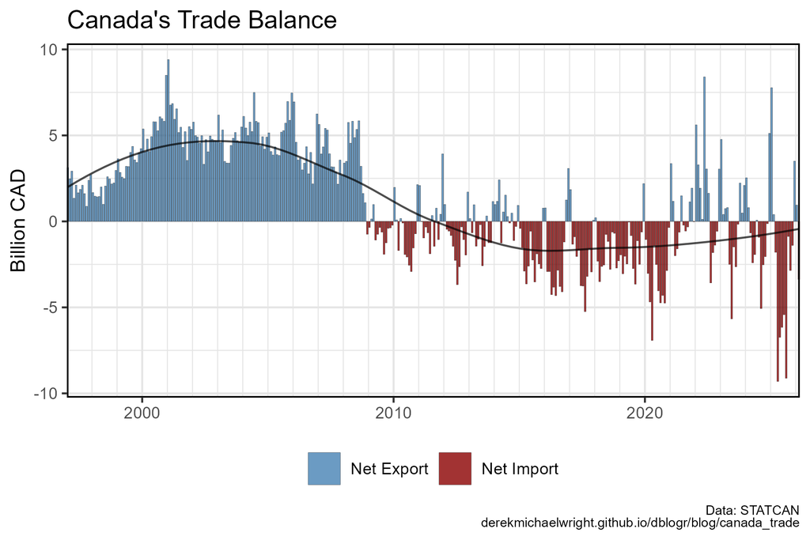

#### gapminder

**gapminder**

Graphs with gapminder data

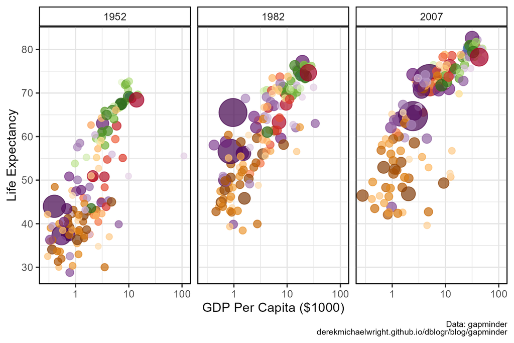

#### Canada Auto Sales

**Automobile Sales in Canada**

Graphs of new motor vehicle sales using STATCAN data

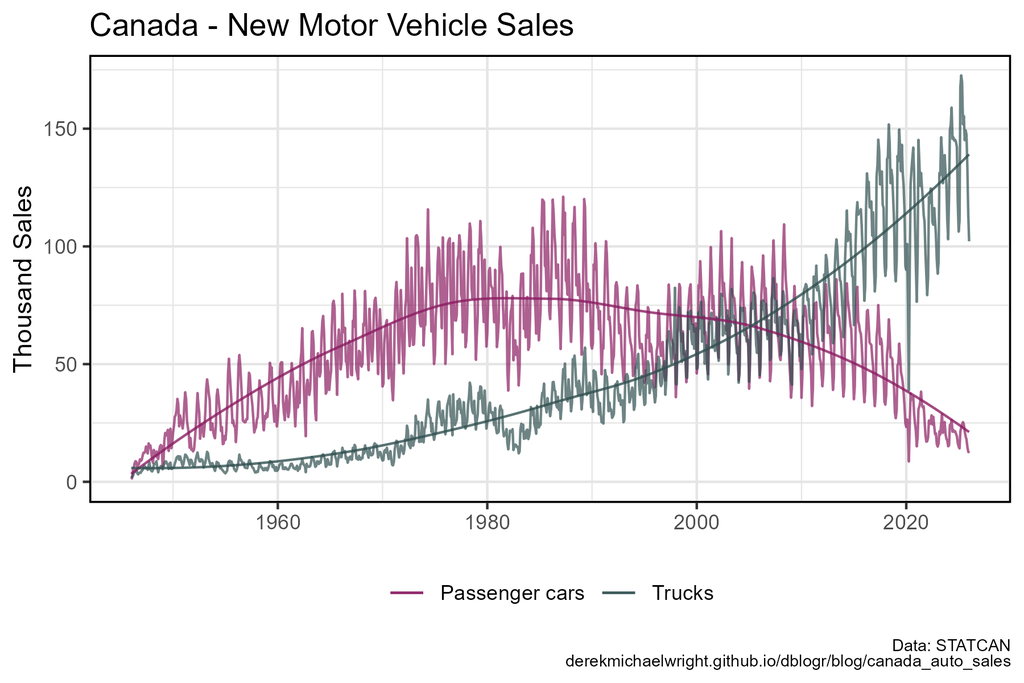

### Demographics

#### Canada Population

**Population Demographics In Canada**

Graphs of population demographics in Canada using STATCAN data

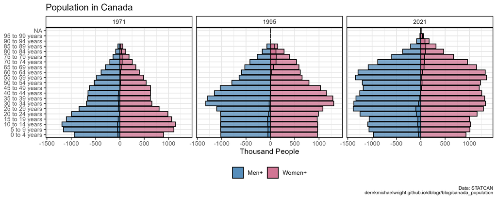

#### Canada Migration

**Migration Demographics In Canada**

Graphs of migration demographics in Canada using STATCAN data

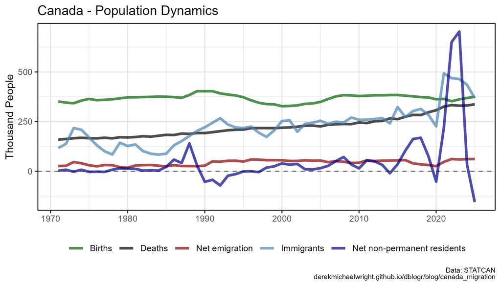

#### USA Population

**USA Population Demographics**

Graphs of population demographics in USA using Census Bureau data

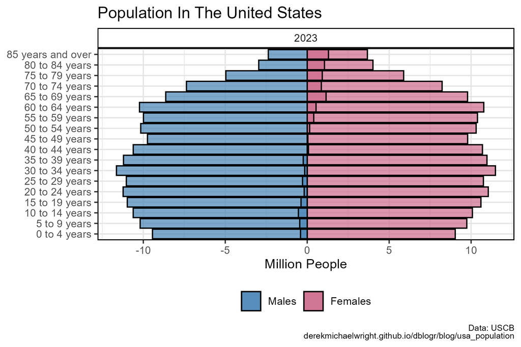

#### Canada Overdoses

**Overdose Deaths In Canada**

Graphs of yearly overdose deaths in Canada using GOV CA, SK & BC data

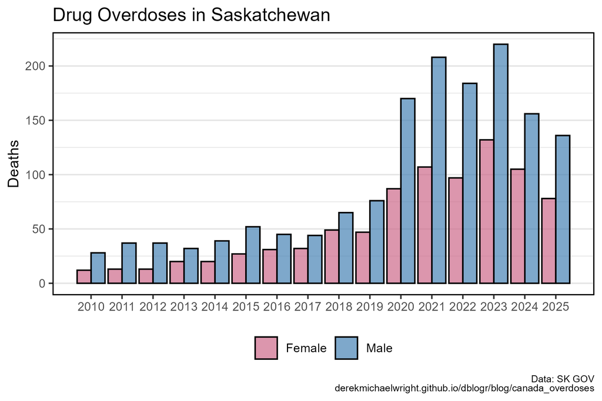

#### USA Overdoses

**Overdose Deaths In The USA**

Graphs of weekly overdose deaths in the USA using CDC data

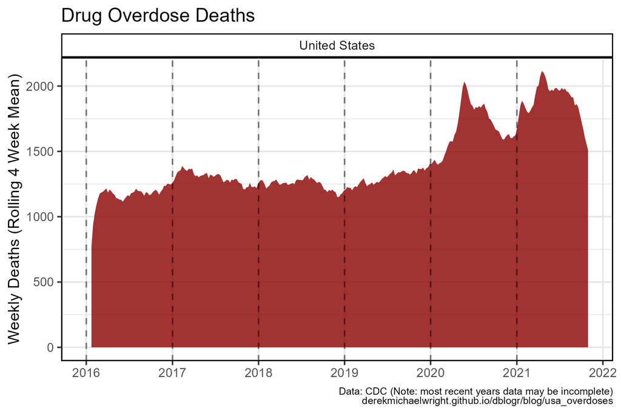

#### Saskatchewan Suicides

**Suicides In Saskatchewan**

Graphs of yearly suicides in Saskatchewan using SK GOV data

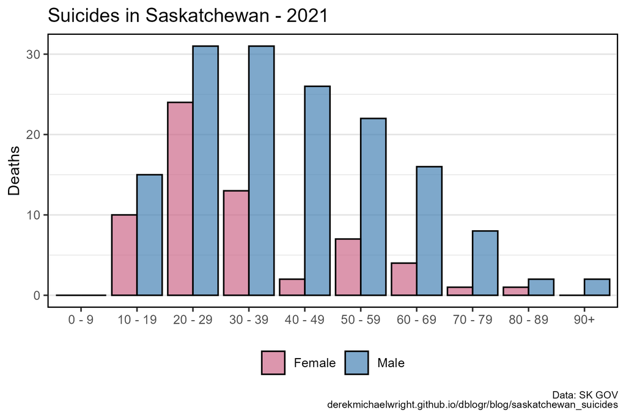

#### Canada Deaths

**Deaths In Canada**

Graphs of weekly deaths in Canada using STATCAN data

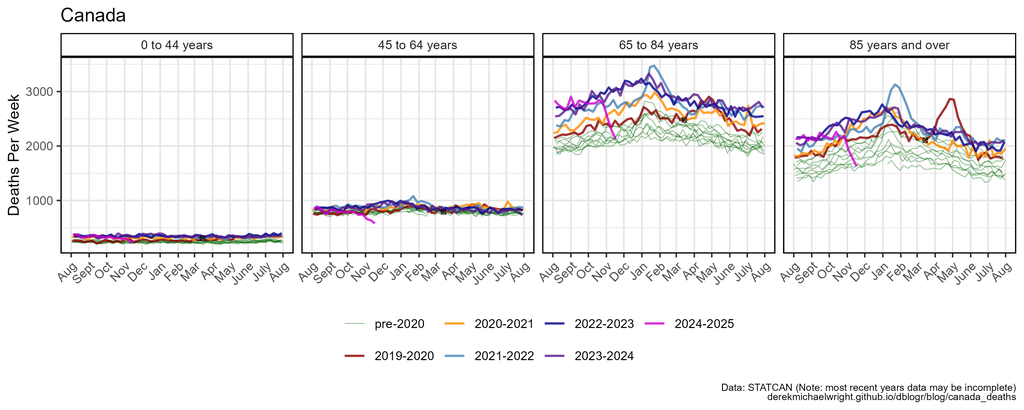

#### USA Deaths

**Deaths In The United States**

Graphs of weekly deaths in the USA using CDC & USCB data

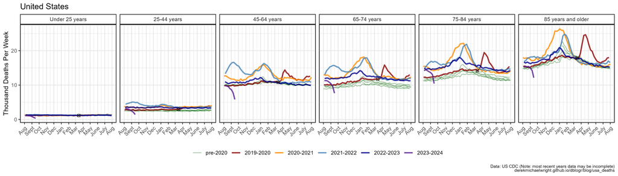

#### Canada Crime

**Crime in Canada**

Graphs of crime statistics using STATCAN data

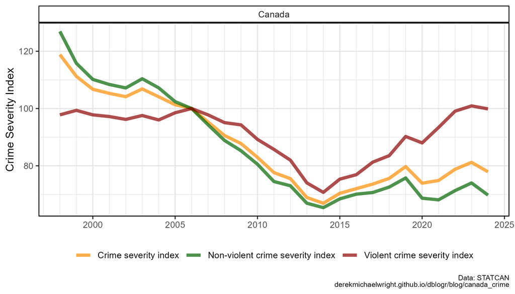

### Politics

#### Saskatchewan Elections

**Saskatchewan Election Results**

Graphs of the 2020 & 2024 Saskatchewan Provincial Election Results

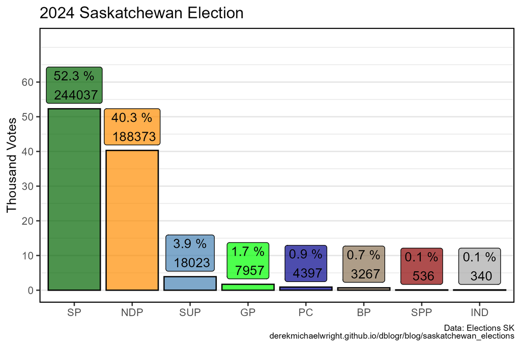

### Other Stuff, *etc*.

#### Hex Stickers

**Hex Stickers**

Creation of hex stickers with R

[figure not shown]

#### Street Maps

**Street Maps**

Create street map art with R and road network files

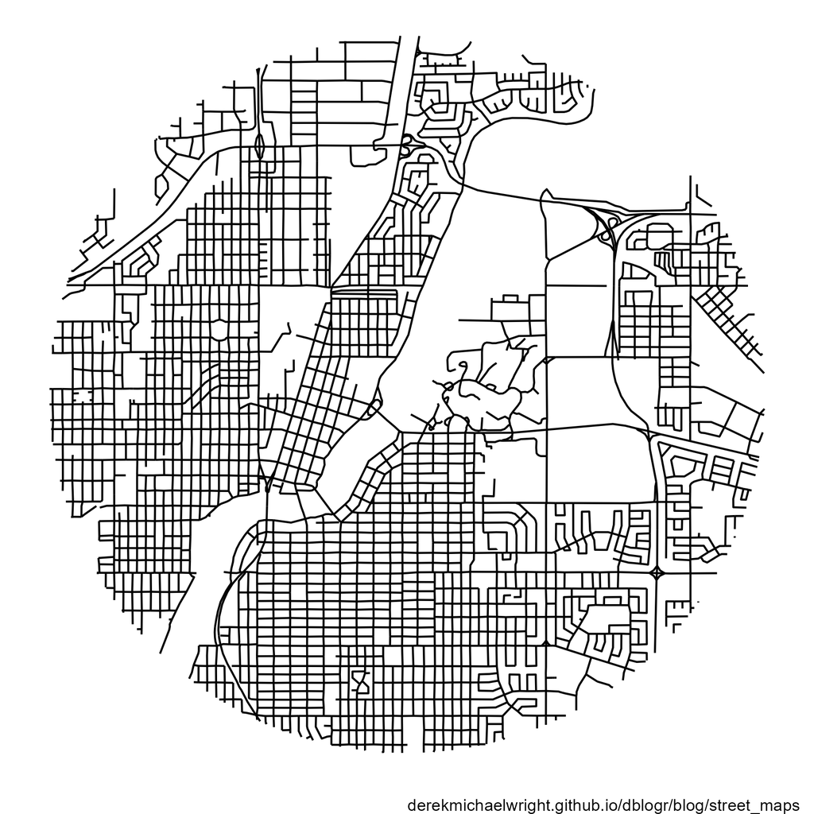

#### starBliss

**starBliss**

Graphs of star constellations using the starBliss R package

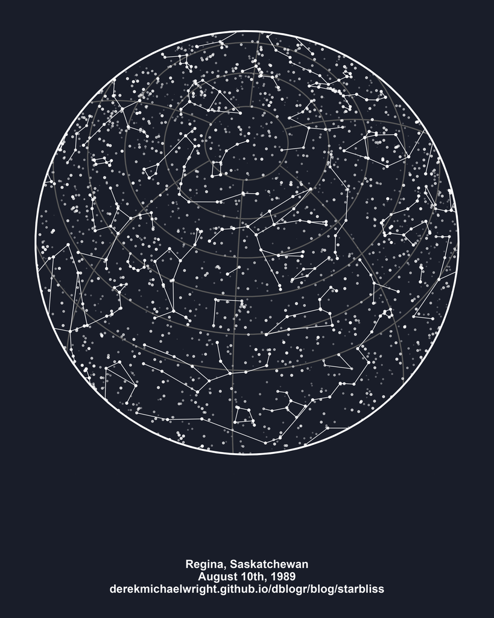

# Photography

## Photo Albums

> Note: Under construction

### AGILE

**Work Photography**

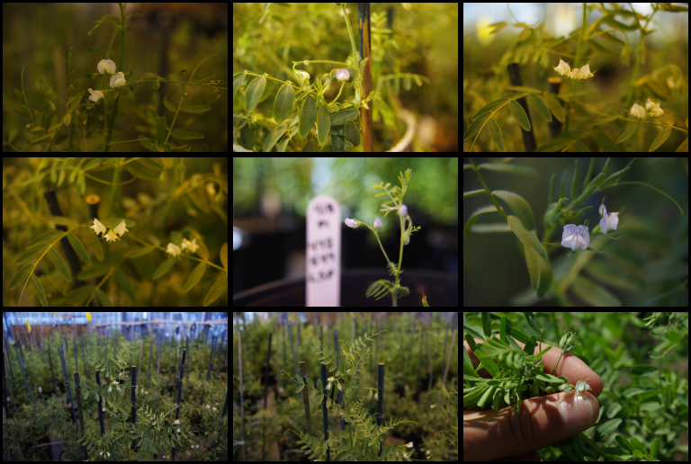

### General

**General Photography**

Some of my photography work

[figure not shown]

### Saskatchewan

**Photography in Saskatchewan**

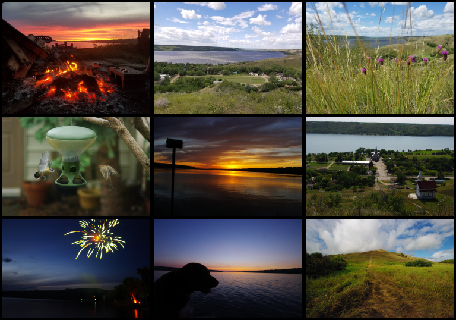

### Mountains

**Photography in the Mountains**

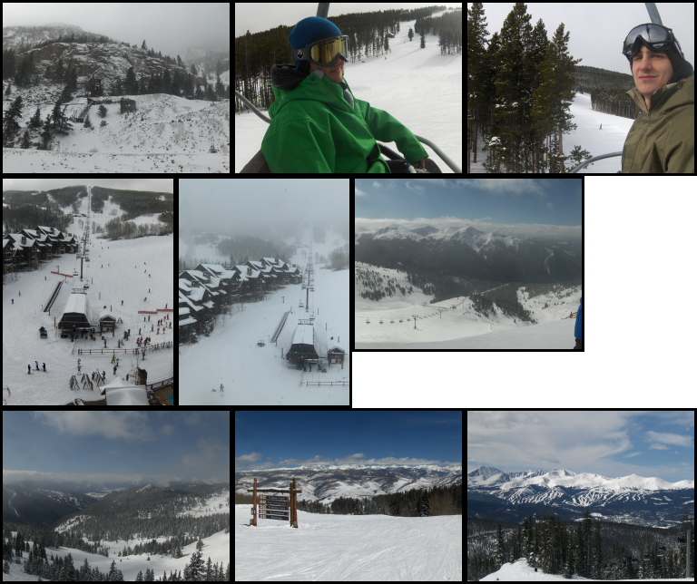

“We shall go into the pyre—we shall burn. But we shall not retreat from our convictions.”

“All thoughts of rest must be forsaken. Sustained efforts are necessary to complete the revolution in agriculture.”

-Nikolai Vavilov

“Extraordinary claims require extraordinary evidence.”

-Carl Sagan

“That which can be asserted without evidence, can be dismissed without evidence.”

-Christopher Hitchens

“I would rather have questions that can’t be answered than answers that can’t be questioned.”

-Richard Feynman

“Think For Yourself, Question Authority.”

-Timothy Leary

“Whoever controls the people’s fears becomes master of their souls.”

-Niccolò Machiavelli

“All animals are equal, but some animals are more equal than others.”

-George Orwell

“It’s amazing how much panic one honest man can spread among a multitude of hypocrites.”

-Thomas Sowell

“In questions of science, the authority of a thousand is not worth the humble reasoning of a single individual.”

-Galileo Galilei

“Comedy is surprises, so if you’re inteding to make somebody laugh and they don’t laugh, that’s funny.”

-Norm MacDonald

“Karl Marx was right, socialism works, it is just that he had the wrong species.”

-Edward O. Wilson

“Growing up, I was free in my childhood years. And now they tell me I can wash away my tears. These tears explain the way, it’s the way that I feel, because the freedom they give me ain’t real.

I want freedom, the kind that they promised me, just for livin’ in this country. I want the freedom, the kind that makes me feel strong, but, let me tell you, something is wrong.”

-Grand Funk Railroad

“Following our will and wind, we may just go where no one’s been. We’ll ride the spiral till the end and may just go where no one’s been.”

-Tool

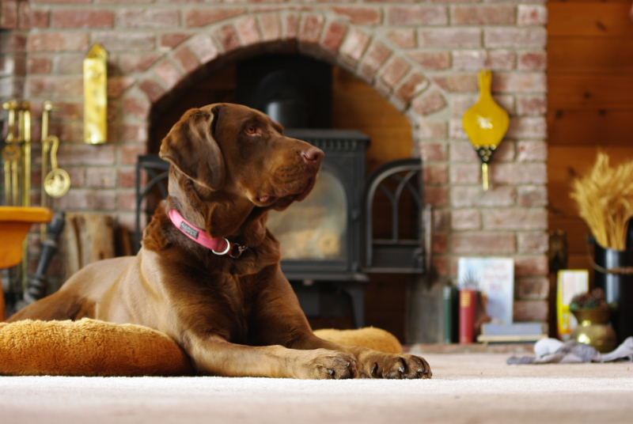

[derekmichaelwright.github.io/dblogr/](https://derekmichaelwright.github.io/dblogr)

© Derek Michael Wright